# NZ GREEN Grid Household Electricity Demand Data

EECA Data Analysis (Part C) Upscaling Advice Report v0.5

Ben Anderson

Last run at: 2019-10-17 19:26:16 (Pacific/Auckland)

# 1 About

## 1.1 Citation

If you wish to use any of the material from this report please cite as:

- Ben Anderson (2019) *NZ GREEN Grid Household Electricity Demand Data: EECA Data Analysis (Part C) Upscaling Advice Report v0.5*, [Centre for Sustainability](http://www.otago.ac.nz/centre-sustainability/), University of Otago: Dunedin.

This work is (c) 2019 the authors. Usage right are specified in the License section (1.3).

## 1.2 Report circulation

- Public – this report is intended for publication following EECA approval.

## 1.3 License

This work is made available under the Creative Commons [Attribution-ShareAlike 4.0 International (CC BY-SA 4.0) License](https://creativecommons.org/licenses/by-sa/4.0/).

This means you are free to:

- *Share* — copy and redistribute the material in any medium or format
- *Adapt* — remix, transform, and build upon the material for any purpose, even commercially.

Under the following terms:

- *Attribution* — You must give appropriate credit, provide a link to the license, and indicate if changes were made. You may do so in any reasonable manner, but not in any way that suggests the licensor endorses you or your use.
- *ShareAlike* — If you remix, transform, or build upon the material, you must distribute your contributions under the same license as the original.
- *No additional restrictions* — You may not apply legal terms or technological measures that legally restrict others from doing anything the license permits.

**Notices:**

- You do not have to comply with the license for elements of the material in the public domain or where your use is permitted by an applicable exception or limitation.
- No warranties are given. The license may not give you all of the permissions necessary for your intended use. For example, other rights such as publicity, privacy, or moral rights may limit how you use the material.

For the avoidance of doubt and explanation of terms please refer to the full [license notice](https://creativecommons.org/licenses/by-sa/4.0/) and [legal code](https://creativecommons.org/licenses/by-sa/4.0/legalcode).

## 1.4 History

You may not be reading the most recent version of this report. Please check:

- the github [R code repository](https://cfsotago.github.io/GREENGridEECA/);
- our [issues list](https://github.com/CfSOtago/GREENGridEECA/issues) for any unfixed problems;
- our [project documentation site](https://cfsotago.github.io/GREENGridEECA/) and specifically;
- this [report’s edit history](https://github.com/CfSOtago/GREENGridEECA/commits/master/reports/partA_dataProcessing)

## 1.5 Support

This work was supported by:

- The New Zealand Energy Efficiency and Conservation Authority ([EECA](https://www.eeca.govt.nz/))

# 2 Introduction

Previous work conducted as part of this project has calculated the % contribution to peak power load (kW) and to overall annual consumption (kWh) for the ~ 40 New Zealand GREEN Grid household electricity demand study dwellings (Stephenson et al. 2017).

EECA have expressed an interest in understanding how these results and/or this sample of dwellings can be scaled up to provide estimates of the same values for the overall New Zealand residential dwelling stock/household population.

Nevertheless it is still useful to review potential upscaling methods should we wish to make assumptions of this kind or for a future time when a larger and representative sample of New Zealand household’s energy consumption data is available. It is possible, for example, that BRANZ’s planned new Household Energy End-Use Project ([HEEP](https://www.branz.co.nz/heep)) version 2 could provide just such a data source.

# 3 Data

A number of data sources are used in this report.

## 3.1 Census 2013

This data comprises family, household or dwelling counts (depending on the variables of interest) at area unit level. The data was downloaded from the Stats NZ census table download tool and processed using [code](https://git.soton.ac.uk/ba1e12/spatialec/blob/master/dataProcessing/processCensusAu2013.Rmd) developed as part of the EU H2020 Marie Skłodowska-Curie scheme-funded [SPATIALEC](http://www.energy.soton.ac.uk/tag/spatialec/) Global Fellowship hosted by the University of Otago.

## 3.2 Grid exit point kWh export (GXP)

This data comprises the half-hourly electricity export (kWh) data for each New Zealand Grid Exit Point for [2015](https://cfsotago.github.io/GREENGridEECA/gxpReport_v0.5.html) downloaded from the Electricity Authority EMI [grid export database](https://www.emi.ea.govt.nz/Wholesale/Datasets/Metered_data/Grid_export). We use this data to provide *total* electricity consumption levels against which we can compare our various residential consumption estimates.

## 3.3 NZ GREEN Grid Household Electricity Demand

This sample comprises 44 households who were recruited via the local power lines companies in two areas: Taranaki starting in May 2014 and Hawkes Bay starting in November 2014 (Anderson and Eyers 2018).

> XX Should this content go in the Part B report to prevent readers of Part B thinking the results are likely to be representative of all NZ dwellings?

Recruitment was via a non-random sampling method and a number of households were intentionally selected for their ‘complex’ electricity consumption (and embedded generation) patterns and appliances (Giraldo Ocampo 2015; Stephenson et al. 2017; Jack et al. 2018; Suomalainen et al. 2019).

The lines companies invited their own employees and those of other local companies to participate in the research and ~80 interested potential participants completed short or long forms of the Energy Cultures 2 household survey (Wooliscroft 2015). Households were then selected from this pool by the project team based on selection criteria relevant to the GREEN Grid project. These included:

- having the majority of their energy supply from electricity (i.e. not gas heating);
- presence of children;
- family and dwelling size;
- types of appliances owned.

As a result of this process the sample cannot be assumed to represent the population of customers (or employees) of any of the companies involved, nor the populations in each location or New Zealand dwellings as a whole (Stephenson et al. 2017).

### 3.3.1 Heating

As an example Figure 3.1 compares the ‘main method of heating’ for the GREEN Grid sample with the results from the BRANZ Housing Conditions Survey 2015 (Vicki White and Mark Jones 2017) where comparable. As we can see the GREEN Grid sample has a higher use of heat pumps compared to the HCS 2015 estimate of 40% heat pump penetration for owner occupied dwellings (the most similar to the GREEN Grid sample) and 25% for rentals. On the other hand, 25% of the GREEN Grid sample used enclosed woodburners as a main method of heating compared to HCS 2015 estimates of 39% and 23% for owner-occupied and rental dwellings respectively. Relatively few GREEN Grid dwellings used portable electric and none used portable gas heaters compared to the HCS 2015 sample.

These results suggest that the pattern of electricity use for space heating in the GREEN Grid sample is unlikely to be representative of all New Zealand dwellings.

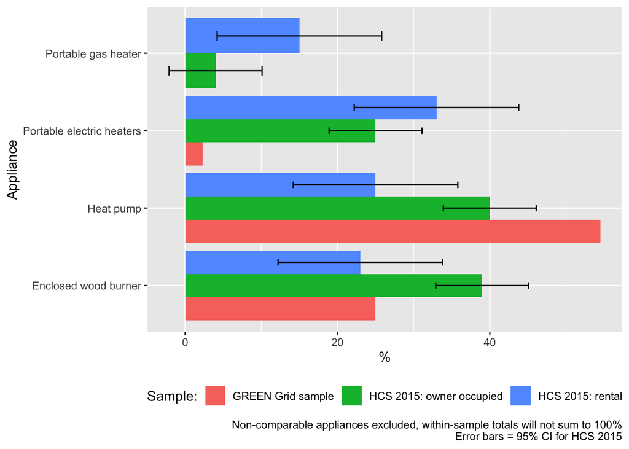

Figure 3.1: Comparison of GREEN Grid and HCS 2015 heating appliance ownership rates

Further, Table 3.1 compares the ‘Fuel type used to heat dwelling’ for Census 2013 and the ‘methods available for heating your house’ in the GREEN Grid sample. Note that mutiple responses were possible in both data sources and we have [coded](https://git.soton.ac.uk/ba1e12/spatialec/blob/master/dataProcessing/processGreenGridSurvey.R) the responses to be as comparable as possible.

Table 3.1: Comparing heating fuel used/methods available (% of dwellings)

| Electricity | Gas | Wood | Coal | Other | source |
| --- | --- | --- | --- | --- | --- |
| 50.65 | 17.18 | 23.03 | 2.59 | 6.55 | Census 2013 (all regions) |
| 67.52 | 32.09 | 46.05 | 1.60 | 7.93 | Census 2013 (Taranaki & Hawke’s Bay only) |
| 54.29 | 11.43 | 22.86 | 0.00 | 11.43 | GREEN Grid sample |

Note:  
Row totals may sum to more than 100% due to multiple responses Open fire is coded as ‘Other’ in GREEN Grid - it is not clear how this is coded in the Census data

Table 3.1 shows that the GREEN Grid sample has a similar ‘available fuel’ profile to New Zealand dwellings as a whole but is not representative of the combined regions of Taranaki and Hawke’s Bay from which it was drawn. In particular there are lower rates of Gas and Wood and much higher ‘Other’ although as noted the latter may be a coding artefact.

### 3.3.2 Number of rooms

Table 3.2: Comparing number of rooms per dwelling (% of dwellings)

| nRooms1_4 | nRooms5_6 | nRooms7m | source |
| --- | --- | --- | --- |
| 15.63 | 40.23 | 44.13 | Census 2013 (all regions) |
| 12.88 | 42.97 | 44.19 | Census 2013 (Taranaki & Hawke’s Bay only) |
| 7.14 | 42.86 | 50.00 | GREEN Grid sample |

### 3.3.3 Number of people

| N people | N | % |
| --- | --- | --- |
| NA | 2 | 4.55 |
| 1 | 4 | 9.09 |
| 2 | 10 | 22.73 |
| 3 | 8 | 18.18 |
| 4 | 14 | 31.82 |
| 5 | 5 | 11.36 |
| 6 | 1 | 2.27 |

### 3.3.4 Number of children

# 4 Scaling examples

## 4.1 Simple multiplication

### 4.1.1 Example: Total electricity consumption

In this case we use the half-hourly total kW load data set produced in [Part A](https://cfsotago.github.io/GREENGridEECA/partA_dataProcessingReport_v1.0.html#610_total_load). To produce national estimates we first prepare the household level consumption data to provide mean energy consumption (kWh) per half-hour for each season in 2015. We use kWh to enable comparison with the GXP data used in [Part B](https://cfsotago.github.io/GREENGridEECA/partB_dataAnalysisReport_v1.0.html#42_regionnetwork_coincident_peak).

```
## Date in ISO8601 format; converting timezone from UTC to "Pacific/Auckland".
```

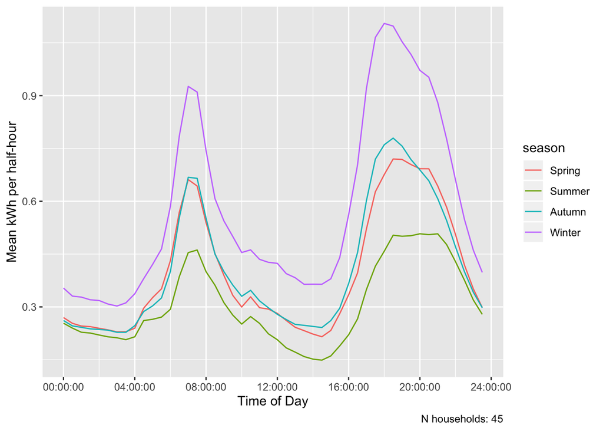

Figure 4.1: Mean kWh per half-hour by season

Figure 4.1 shows the mean kWh per half hour for each season that we will use as the basis for the re-weighting process. We can therefore estimate that the maximum mean kWh per half-hour in winter is ~ 1.11 kWh. If we multiply this by the number of households in New Zealand as recorded by the 2013 Census (1,796,000) then we get a rough estimate of maximum mean residential kWh in winter as 1.99 GWh.

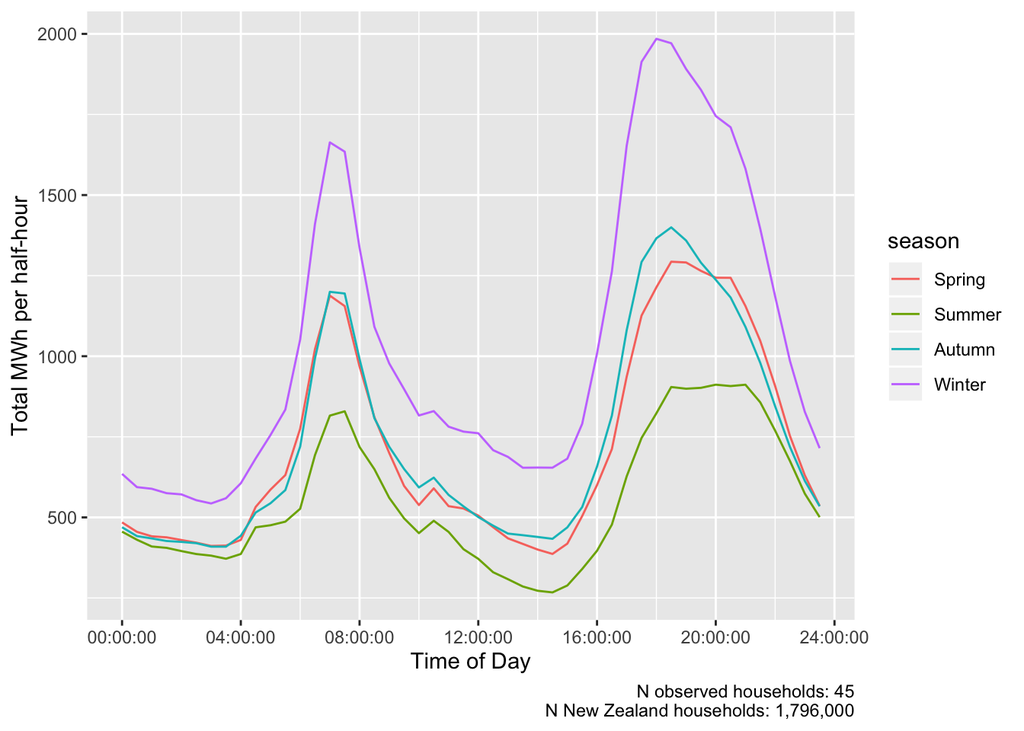

Figure 4.2: Total residential electricity consumption per half-hour by season

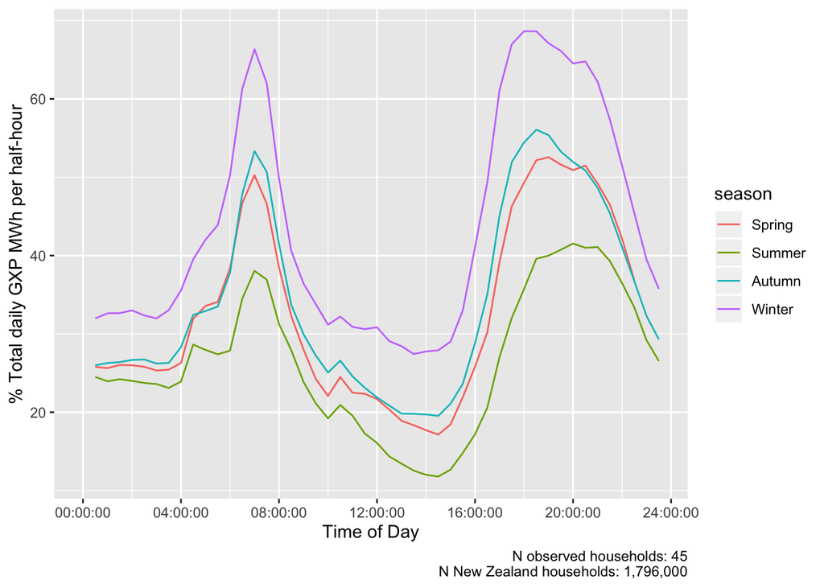

This approach illustrates the difficulty of producing robust national level using simple multiplication of a small and biased sample.

## 4.2 Simple Proportional Upscaling

### 4.2.2 Summary

## 4.3 Complex re-weighting

- Taranaki
- Hawke’s Bay
- NZ

### 4.3.3 Sumary

# 5 Overall summary and recommendations

This report has outlined a number of methods that could be used to upscale the GREEN Grid (or similar) household energy demand datasets to develop national or regional level residential demand or consumption estimates. However we have noted that in all cases the GREEN grid data is insufficient for this purpose due to:

- its small size - meaning very small numbers of households would be ‘representing’ very large numbers in the true population;
- its recruitment bias - meaning that some household types and some crucial energy source types (e.g. coal, wood-only, reticulated gas) are not represented at all and so cannot be ‘re-weighted’.

We have demonstrated this through a number of worked examples and suggest that future work could apply these methods to more suitable data sources such as:

All code used to create this report is available from:

- https://github.com/CfSOtago/GREENGridEECA

The archived and most recent version of the report is available from:

- https://cfsotago.github.io/GREENGridEECA/

# 6 Data Annex

## 6.3 GREEN Grid household data summary

# 7 Runtime

Analysis completed in 21.04 seconds ( 0.35 minutes) using knitr in [RStudio](http://www.rstudio.com) with R version 3.5.2 (2018-12-20) running on x86_64-apple-darwin15.6.0.

# 8 R environment

## 8.1 R packages used

- base R (R Core Team 2016)
- bookdown (Xie 2016a)
- data.table (Dowle et al. 2015)
- ggplot2 (Wickham 2009)
- kableExtra (Zhu 2018)
- knitr (Xie 2016b)
- lubridate (Grolemund and Wickham 2011)
- rmarkdown (Allaire et al. 2018)

# References

Allaire, JJ, Yihui Xie, Jonathan McPherson, Javier Luraschi, Kevin Ushey, Aron Atkins, Hadley Wickham, Joe Cheng, and Winston Chang. 2018. *Rmarkdown: Dynamic Documents for R*. https://CRAN.R-project.org/package=rmarkdown.

Anderson, Ben. 2012. “Estimating Small Area Income Deprivation: An Iterative Proportional Fitting Approach.” In *Spatial Microsimulation: A Reference Guide for Users*, edited by Kimberley Edwards and R Tanton. London: Springer.

———. 2019. “Small Area Temporal Household Electricity Demand Microsimulation Models for New Zealand: Why, How and How Far Have We Got?” In. Christchurch, Aotearoa New Zealand.

Anderson, Ben, and David Eyers. 2018. *GREENGridData: Processing Nz Green Grid Project Data to Create a ’Safe’ Version for Data Archiving and Re-Use*. https://github.com/CfSOtago/GREENGridData.

Anderson, Ben, Tom Rushby, Abubakr Bahaj, and Patrick James. 2020. “Ensuring Statistics Have Power: Guidance for Designing, Reporting and Acting on Electricity Demand Reduction and Behaviour Change Programs.” *Energy Research & Social Science* 59 (January): 101260. https://doi.org/10.1016/j.erss.2019.101260.

Dortans, Carsten. 2019. “Estimating the Technical Potential for Residential Household Appliances to Reduce Daily Peak Electricity Demand in New Zealand.” Master’s thesis, University of Otago: Dunedin: Centre for Sustainability.

Dowle, M, A Srinivasan, T Short, S Lianoglou with contributions from R Saporta, and E Antonyan. 2015. *Data.table: Extension of Data.frame*. https://CRAN.R-project.org/package=data.table.

Giraldo Ocampo, Diana. 2015. “Developing an Energy-Related Time-Use Diary for Gaining Insights into New Zealand Households’ Electricity Consumption.” Master’s thesis, Centre for Sustainability: University of Otago. http://hdl.handle.net/10523/5957.

Grolemund, Garrett, and Hadley Wickham. 2011. “Dates and Times Made Easy with lubridate.” *Journal of Statistical Software* 40 (3): 1–25. http://www.jstatsoft.org/v40/i03/.

Jack, M. W., K. Suomalainen, J. J. W. Dew, and D. Eyers. 2018. “A Minimal Simulation of the Electricity Demand of a Domestic Hot Water Cylinder for Smart Control.” *Applied Energy* 211: 104–12. https://www.sciencedirect.com/science/article/pii/S0306261917316197.

R Core Team. 2016. *R: A Language and Environment for Statistical Computing*. Vienna, Austria: R Foundation for Statistical Computing. https://www.R-project.org/.

Stephenson, Janet, Rebecca Ford, Nirmal-Kumar Nair, Neville Watson, Alan Wood, and Allan Miller. 2017. “Smart Grid Research in New Zealand–A Review from the GREEN Grid Research Programme.” *Renewable and Sustainable Energy Reviews* 82 (1): 1636–45. https://doi.org/10.1016/j.rser.2017.07.010.

Suomalainen, Kiti, David Eyers, Rebecca Ford, Janet Stephenson, Ben Anderson, and Michael Jack. 2019. “Detailed Comparison of Energy-Related Time-Use Diaries and Monitored Residential Electricity Demand.” *Energy and Buildings* 183: 418–27. https://doi.org/10.1016/j.enbuild.2018.11.002.

Vicki White, and Mark Jones. 2017. “Warm, Dry, Healthy? Insights from the 2015 House Condition Survey on Insulation, Ventilation, Heating and Mould in New Zealand Houses.” SR 372. Porirua, New Zealand: BRANZ Ltd.

Wickham, Hadley. 2009. *Ggplot2: Elegant Graphics for Data Analysis*. Springer-Verlag New York. http://ggplot2.org.

Wooliscroft, B. 2015. “National Household Survey of Energy and Transportation: Energy Cultures Two.” Centre for Sustainability: University of Otago. http://hdl.handle.net/10523/5634.

Xie, Yihui. 2016a. *Bookdown: Authoring Books and Technical Documents with R Markdown*. Boca Raton, Florida: Chapman; Hall/CRC. https://github.com/rstudio/bookdown.

———. 2016b. *Knitr: A General-Purpose Package for Dynamic Report Generation in R*. https://CRAN.R-project.org/package=knitr.

Zhu, Hao. 2018. *KableExtra: Construct Complex Table with ’Kable’ and Pipe Syntax*. https://CRAN.R-project.org/package=kableExtra.